# Tema 1 - Números reales

## Introducción

## Cálculo: Las Matemáticas del cambio

El término Cálculo identifica un conjunto de instrumentos matemáticos para efectuar medidas.

El Cálculo Diferencial trata de la medida de tasas de variación: objetos en movimiento, crecimiento de seres vivos, transmisión de calor, campos electromagnéticos y un largo etcétera.

Por su parte, el Cálculo Integral, trata de medidas de longitudes, áreas, volúmenes, flujos de fluidos, \(\ldots\)

Los números reales, \(\mathbb{R}\), proporcionan la base para expresar los resultados de estas medidas. Por ello empezaremos describiendo estos números, su estructura y propiedades más significativas.

## Números y medida: El conjunto \(\mathbb{N}\) de los números naturales

Los números naturales \(\mathbb{N} = \{1,2,3, \ldots ,n, \ldots \}\)

**Suma de números naturales:**

PC. Propiedad conmutativa: \(m+n =n+m\), para todo \(m,n \in \mathbb{N}\)

PA. Propiedad asociativa: \(m+(n+p) = (m+n)+p\), para todo \(m,n,p \in \mathbb{N}\)

## Números y medida: El conjunto \(\mathbb{N}\) de los números naturales

**Producto de números naturales:**

EN. Elemento neutro, \(1\): \(n \times 1 = 1 \times n =n\), para todo \(n \in \mathbb{N}\).

PC. Propiedad conmutativa: \(n \times m = m \times n\), para todo \(m,n \in \mathbb{N}\).

PA. Propiedad asociativa: \(n\times (m \times p) = (n \times m)\times p\), para todo \(m,n,p \in \mathbb{N}\)

PD. Propiedad distributiva del producto respecto de la suma: \(m \times (n+p) = m\times n +m\times p\), para todo \(m,n,p \in \mathbb{N}\).

## El conjunto \(\mathbb{N}\) de los números naturales.

**Principio de inducción**:

Si un subconjunto \(A\) de números naturales es tal que

1. \(1 \in A\), y
2. Siempre que \(n \in A\) es \(n+1 \in A\)

entonces \(A = \mathbb{N}\).

**Principio de la buena ordenación**:

Todo subconjunto de números naturales no vacío tiene primer elemento.

## Principio de inducción: **Ejemplos**

**Ejemplos**

**Ejemplo 1**. Demuestra que para todo \(n\in \mathbb{N}\) se verifica que \(2^{n-1}\leq n!\).

Efectivamente: para \(n=1\) tenemos que \(1=2^0 \leq 2 =2!\). Supongamos que es cierto para \(n=k-1\), es decir que \(2^{k-2} \leq (k-1)!\), entonces \(2^{k-1} = 2\cdot 2^{k-2} \leq 2 \cdot (k-1)! \leq k\cdot(k-1)! =k!\), puesto que \(2\leq k\). En definitiva es \(2^{n-1}\leq n!\) para todo \(n \in \mathbb{N}\)

**Ejemplo 2**. Demuestra que, para todo \(n \in \mathbb{N}\) se verifica que \(\displaystyle{\sum_{k=1}^n k = \frac{n(n+1)}{2}}\).

En primer lugar, para \(k=1\) la igualdad se verifica puesto que las dos expresiones son iguales a \(1\). Supongamos que es cierta hasta \(n-1\) es decir que \(\displaystyle{\sum_{k=1}^{n-1} k = \frac{(n-1)n}{2}}\), entonces \[ \sum_{k=1}^n k = \frac{n(n+1)}{2} = n+\sum_{k=1}^{n-1} k = n+ \frac{(n-1)n}{2}= \frac{2n+n^2-n}{2} = \frac{n(n+1)}{2} \] Por lo tanto la igualdad es cierta para todo \(n \in \mathbb{N}\)

## Números y medida: El conjunto \(\mathbb{Z}\) de los números enteros

Los números enteros \(\mathbb{Z} = \{ \ldots ,-n, \ldots -3,-2,-1,0,1,2,3, \ldots , n \ldots\}\)

**Suma:**

EN. Elemento neutro, \(0\): \(a+0=0+a=a\), para todo \(a \in \mathbb{Z}\)

ES. Elemento simétrico, \(-a\): \(a +(-a) = -a+a = 0\), \(a \in \mathbb{Z}\).

PC. Propiedad conmutativa: \(a+b =b+a\), para todo \(a,b \in \mathbb{Z}\)

PA. Propiedad asociativa: \(a+(b+c) = (a+b)+c\), para todo \(a,b,c \in \mathbb{Z}\)

## Números y medida: El conjunto \(\mathbb{Z}\) de los números enteros

**Producto:**

EN. Elemento neutro, \(1\): \(a \times 1 = 1 \times a =a\), para todo \(a \in \mathbb{Z}\).

PC. Propiedad conmutativa \(a \times b = b \times a\), para todo \(a,b \in \mathbb{Z}\).

PA. Propiedad asociativa: \(a\times (b \times c) = a \times b)\times c\), para todo \(a,b,c \in \mathbb{Z}\)

PD. Distributiva del producto respecto de la suma: \(a \times (b+c) = a\times b +a \times c\), para todo \(a,b,c \in \mathbb{Z}\).

## El conjunto \(\mathbb{Z}\) de los números enteros

**División entera**

Dados dos números enteros \(a\) y \(b\), existen otros dos enteros \(q\) y \(r\), con \(0 \leq r<q\) tales que

\[ a=bq+r \] \(q\): cociente, \(r\): resto

Si \(r=0\), entonces decimos que \(a\) es un **múltiplo** de \(b\) y tambien que \(b\) es un **divisor** de \(a\)

Si \(r>0\) entonces \(a\) y \(b\) son **primos** entre si.

## Números y medida: El conjunto \(\mathbb{Q}\) de los números racionales

Los números racionales: \(\mathbb{Q} = \left\{ \dfrac{p}{q}: p,q \in \mathbb{Z}, q \neq 0 \right\}\)

**Suma:**

EN. Elemento neutro, \(0\): \(p+0=0+p=p\), para todo \(p \in \mathbb{Q}\)

ES. Elemento simétrico, \(-p\): \(p +(-p) = -p+p = 0\), \(p \in \mathbb{Q}\).

PC. Propiedad conmutativa: \(p+q =q+p\), para todo \(p,q \in \mathbb{Q}\)

PA. Propiedad asociativa: \(p+(q+r) = (p+q)+r\), para todo \(p,q,r \in \mathbb{Q}\)

## Números y medida: El conjunto \(\mathbb{Q}\) de los números racionales

**Producto:**

EN. Elemento neutro, \(1\): \(p \cdot 1 = 1 \cdot p =p\), para todo \(p \in \mathbb{Q}\).

ES. Elemento simétrico, \(\dfrac{1}{p}\). \(p \cdot \dfrac{1}{p} = \dfrac{1}{p} \cdot p =1\), para todo \(p \in \mathbb{Q}\), \(p \neq 0\)

PC. Propiedad conmutativa \(p \cdot q = q \cdot p\), para todo \(p,q \in \mathbb{Q}\).

PA. Propiedad asociativa: \(p\cdot (q \cdot r) = p \cdot q)\cdot r\), para todo \(p,q,r \in \mathbb{Q}\)

PD. Distributiva del producto respecto de la suma: \(p \cdot (q+r) = p \cdot q + p \cdot r\), para todo \(p,q,r \in \mathbb{Q}\).

## El conjunto \(\mathbb{Q}\) de los números racionales

Orden: El conjunto de los racionales está ordenado de la forma \[ \dfrac{p}{q} \leq \dfrac{r}{s} \quad \text{ si } \quad p\cdot s \leq p \cdot r \]

Se trata de un orden denso: Dados dos números racionales tales que \(\dfrac{p}{q} < \dfrac{r}{s}\), entonces existen números racionales \(\dfrac{m}{n}\) tales que

\[ \dfrac{p}{q} < \dfrac{m}{n} < \dfrac{r}{s} \]

Es suficiente considerar \(m=p+r\) y \(n=q+s\).

## El conjunto \(\mathbb{Q}\) de los números racionales

Los números racionales no son suficientes puesto que hay medidas cuyo resultado no és un número racional:

- La longitud de la diagonal de un cuadrado con el lado como unidad (\(\sqrt{2}\))
- La longitud de una circunferencia tomando el diámetro como unidad (\(\pi\))

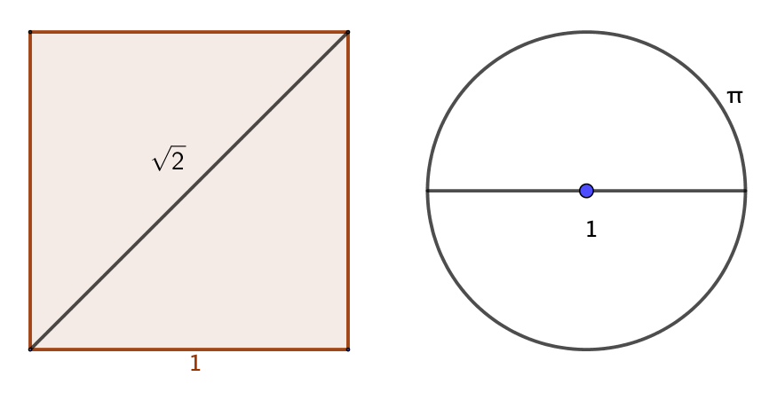

## La raiz cuadrada de 2 no es un número racional, \(\sqrt{2} \notin \mathbb{Q}\)

Proposición

No existe ningún número racional \(q \in \mathbb{Q}\) tal que \(q^2=2\).

**Demostración:**

Supongamos que sí, que para un cierto \(q =\dfrac{a}{b} \in \mathbb{Q}\), es \(q^2=\dfrac{a^2}{b^2} = 2\).

Podemos elegir \(a\) y \(b\) de tal manera que \(\\mcd(a,b)=1\)

Entonces seria \(a^2=2b^2\), lo qual significa que \(a\) es un múltiplo de \(2\).

Dado que se trata de un número primo, debe ser \(a\) un múltiplo de \(2\), es decir \(a=2k\)

Por lo tanto \(a^2 = 4k^2\), lo que significa que \(b^2=2k^2\) y que \(b\) tambien debería ser múltiplo de \(2\), lo que contradice el hecho que \(a\) y \(b\) sean primos entre sí.

## Los números reales: \(\mathbb{R}\)

Supondremos la existencia de un conjunto \(\mathbb{R}\) de números en el que hay definidas dos operaciones, suma y producto, con las siguientes propiedades:

- Propiedades de la suma:
  - Conmutativa: \(a+b= b+a\), para todos los \(a,b \in \mathbb{R}\)
  - Asociativa: \(a+(b+c) = (a+b)+c\) para todos los \(a,b,c \in \mathbb{R}\)
  - Existe un elemento neutro, \(0 \in \mathbb{R}\), para la suma: \(a+0=a=0+a\).
  - Para cada \(a \in \mathbb{R}\) existe un elemento \(-a \in \mathbb{R}\), simétrico de \(a\), tal que \(a+(-a)=0=(-a)+a\)

## Los números reales: \(\mathbb{R}\)

- Propiedades del producto de números reales:
  - Conmutativa: \(a\cdot b=b \cdot a\), para todos los \(a,b \in \mathbb{R}\).
  - Asociativa: \(a \cdot (b \cdot c) = (a\cdot b)\cdot c\) para todos los \(a,b,c \in \mathbb{R}\)
  - Existe un elemento neutro, \(1 \in \mathbb{R}\), para el producto: \(a\cdot1=a=1\cdot a\).
  - Para cada \(a \in \mathbb{R}\), \(a\neq 0\), existe un elemento \(\dfrac{1}{a} = a^{-1} \in \mathbb{R}\), inverso de \(a\), tal que \(a \cdot a^{-1}=1=a ^{-1}\cdot a\)
  - El producto es distributivo respecto de la suma: \(a\cdot (b+c) = a\cdot b + a \cdot c\) para todos los \(a,b,c \in \mathbb{R}\).

## Los números reales incluyen los naturales, enteros y racionales: \(\mathbb{N} \subset \mathbb{Z} \subset \mathbb{Q} \subset \mathbb{R}\)

- Dado que en \(\mathbb{R}\) existe un elemento neutro para el producto, \(1\), podemos asimilar el número natural \(n\) con el número real \(1+ \ldots \overset{n)}{} \ldots + 1\), es decir \(\mathbb{N} \subset \mathbb{R}\)
- Dado que en \(\mathbb{R}\), existe \(-1\), el simétrico de \(1\), podemos asimilar el número entero \(-n\) con el número real \((-1)+(-1)+ \ldots \overset{n)}{} \ldots +(-1)\). En definitiva \(\mathbb{N} \subset \mathbb{Z} \subset \mathbb{R}\)
- Dado que para cada \(a \in \mathbb{R}, \quad a\neq 0\) existe \(\dfrac{1}{a}\), el inverso de \(a\). Entonces para cada \(n,m \in \mathbb{Z}\), con \(m \neq 0\), será \(\dfrac{n}{m} \in \mathbb{R}\), es decir, \(\mathbb{N} \subset \mathbb{Z} \subset \mathbb{Q} \subset \mathbb{R}\).

## El orden en los números reales: \(\mathbb{R}\)

Para definir una relación de orden entre los números reales, supondremos que existe un subconjunto \(P\) de números reales tal que:

\[ P \cup \{ 0 \} \cup (-P) = \mathbb{R} \]

donde \(-P = \{-x: x \in \mathbb{R} \}\), tales que \(P\cap (-P) = \emptyset\).

Es decir, todo número real o está en \(P\) o és igual a \(0\) o su simétrico está en \(P\), y sólo una de estas tres opciones.

Además, \(P\), satisface las propiedades:

1. \(P+P \subset P\), es decir, la suma de dos números de \(P\) és un número de \(P\), y
2. \(P \cdot P \subset P\), el producto de dos números de \(P\) también es un número de \(P\)

## El orden en los números reales

Definición

Dados dos números reales, \(a\) y \(b\), diremos que \(a\) és **menor o igual** que \(b\) y escribiremos \(a \leq b\), si \(b-a \in P \cup \{0\}\).

Es decir, \(a \leq b\) si la diferencia \(b-a\) está en \(P\) o \(a=b\).

Si \(a\neq b\) diremos que \(a\) es estrictamente menor que \(b\) y escribiremos \(a<b\).

Diremos que \(a \geq b\), es decir que \(a\) es **mayor o igual** que \(b\), si \(b \leq a\).

Obsérvese que \(a \in P\) es equivalente a decir que \(a > 0\). De ahí que a los elementos de \(P\) se les llame **números positivos**

## Propiedades del orden en los números reales

Proposición

1. \(a \leq a\) (Propiedad reflexiva),
2. Si \(a \leq b\) y \(b \leq a\), entonces \(a=b\) (Propiedad antisimétrica)
3. Si \(a \leq b\) y \(b \leq c\), entonces \(a \leq c\) (Propiedad transitiva)

**Demostración:**

1. Obviamente \(a-a=0 \in P \cup \{ 0\}\).
2. Si \(a-b\) y \(b-a\) estan los dos en \(P \cup \{ 0\}\), dado que un número y su simétrico no pueden estar a la vez en \(P\), la única posibilidad que queda es que sean iguales, es decir que \(a-b=b-a=0\).
3. Si \(a=b\) o \(b=c\), el resultado es inmediato. Si los tres son diferentes, entonces si \(b-a\) y \(c-b\),estan en \(P\), su suma \((b-a)+(c-b)=c-a\) también está en \(P\), es decir \(a \leq c\).

## Más propiedades del orden en los números reales

Proposición

- Si \(a \in \mathbb{R}\), entonces \(a^2 \in P \cup \{0\}\),
- \(1 \in P\),
- \(\mathbb{N} \subset P\).

**Demostración:**

- \(a\) puede ser de \(P\), \(0\) o de \(-P\). Si es de \(P\), entonces \(a^2 \in P\), por ser el producto de dos elementos de \(P\). Si \(a=0\), entonces \(a^2 = 0\). Finalmente, si \(a \in -P\), entonces \(-a \in P\), por lo que \((-a)(-a) = (-1)a(-1)a=(-1)(-1)aa = a^2\) es decir, \(a^2 \in P\), al ser, nuevamente, el producto de dos elementos de \(P\).
- Inmediato a partir del apartado anterior, puesto que \(1=1^2\)
- Como hemos visto \(n = 1+ \ldots \overset{n)}{} \ldots + 1\), es decir cualquier número natural es la suma de números positivos y, por lo tanto, positivo.

## Más propiedades del orden en \(\mathbb{R}\)

Proposición.

Sean \(a,b, c \in \mathbb{R}\)

1. Si \(a>b\), entonces \(a+c > b+c\).
2. Si \(a>b\) y \(c>d\), entonces \(a+c >b+d\).
3. Si \(a>b\) y \(c>0\), entonces \(ac>bc\).
4. Si \(a>b\) y \(c<0\), entonces \(ac<bc\).
5. Si \(a>0\), entonces \(\dfrac{1}{a} >0\).
6. Si \(a<0\), entonces \(\dfrac{1}{a} <0\)

## Todavía más propiedades del orden en \(\mathbb{R}\)

Proposición.

Sean \(a,b \in \mathbb{R}\)

1. Si \(a < b\) entonces \(a < \dfrac{a+b}{2} <b\).
2. Si \(b>0\), entonces \(0<\dfrac{b}{2} < b\)
3. Si \(0\leq a < \epsilon\) para todo número real positivo \(\epsilon\), entonces \(a=0\).
4. Si \(a-\epsilon < b\) para todo \(\epsilon > 0\), entonces \(a\leq b\)

## Valor absoluto

Definición

Dado un número real \(a\), el **valor absoluto** de \(a\), representado por \(|a|\), es el mayor de los dos valores \(\{a,-a \}\).

Así \(|-3|=3\) y \(|45|=45\), es decir \(|a| = a\), si \(a \geq 0\) y, si \(a <0\), entonces \(|a| = -a\),

Es fácil comprobar que \(|a| = \sqrt{a^2}\).

Un error frecuente que se debe evitar es considerar que \(\sqrt{a^2}=a\).

## Valor absoluto: propiedades

Proposición

- \(|a| \geq 0\) y \(|a|=0\) si, y sólo si, \(a=0\).
- \(|-a|=|a|\), para todo \(a \in \mathbb{R}\).
- \(|ab|= |a||b|\), para toda \(a,b \in \mathbb{R}\).
- Si \(c \geq 0\), entonces \(|a| \leq c\), si y sólo si \(-c \leq a \leq c\)
- \(-|a| \leq a \leq |a|\), para todo \(a \in \mathbb{R}\).

## Desigualdad triangular

Proposición

Para toda \(a,b \in \mathbb{R}\):

- \(|a+b| \leq |a| + |b|\) (Desigualdad triangular).
- \(||a|-|b|| \leq |a-b|\).
- \(|a-b| \leq |a|+|b|\).

**Demostración:**

- Dado que \(-|a| \leq a \leq |a|\) y \(-|b| \leq b \leq |b|\), tenemos que

\[ -(|a|+|b|) \leq a+b \leq |a| + |b| \] es decir, \(|a+b| \leq |a| + |b|\).

- \(|a| = |a-b+b| \leq |a-b| + |b|\), es decir \(|a|-|b| \leq |a-b|\). Análogamente comprobaríamos que \(|b|-|a| \leq |b-a|\).

## Intervalos en \(\mathbb{R}\)

Definición

Dados números reales \(a,b \in \mathbb{R}\) tales que \(a<b\), el **intervalo cerrado de extremos \(a\) y \(b\)** es el conjunto

\[ [a,b] = \{x\in \mathbb{R}: a \leq x \leq b \} \] Por su parte, **intervalo abierto de extremos \(a\) y \(b\)** es el conjunto:

\[ (a,b) = \{x\in \mathbb{R}: a < x < b \} \] **Intervalos semiabiertos:**

\[ (a,b] = \{ x \in \mathbb{R}: a<x \leq b \} \quad \text{ y } \quad [a,b) = \{ x \in \mathbb{R}: a \leq x < b \} \]

## Observación importante sobre el valor absoluto

A menudo usaremos desigualdades del estilo

\[ |x-a|\leq \epsilon \]

De acuerdo con la definición de valor absoluto, esta desigualdad equivale a las dos desigualdades

\[ -\epsilon \leq x-a \leq \epsilon \]

y también

\[ a-\epsilon \leq x \leq a+ \epsilon \]

o, lo que es lo mismo,

\[ x \in [a-\epsilon,a+\epsilon] \]

## Entornos abiertos y cerrados

Las consideraciones anteriores llevan a las siguientes

**Definiciones**

**Entorno abierto:** Dados un punto \(a \in \mathbb{R}\) y un \(\epsilon >0\), el **entorno abierto** de centro \(a\) y radio \(\epsilon\) es el conjunto de puntos \(V_{\epsilon}(a)=\{ x \in \mathbb{R}: |x-a|<\epsilon \} = (a-\epsilon, a+\epsilon)\).

**Entorno cerrado:** Dados un punto \(a \in \mathbb{R}\) y un \(\epsilon >0\), el **entorno cerrado** de centro \(a\) y radio \(\epsilon\) es el conjunto de puntos \(\overline{V}_{\epsilon}(a)=\{ x \in \mathbb{R}: |x-a| \leq \epsilon \} = [a-\epsilon, a+\epsilon]\).

## Entornos abiertos y cerrados

**Definición**

**Entorno reducido** de un punto: un entorno abierto (cerrado) sin el punto, es decir \(V^*_{\epsilon}(a)=V_{\epsilon}(a) \setminus \{a\}\) \(\left(\overline{V}^*_{\epsilon}(a) = \overline{V}_{\epsilon}(a) \setminus \{a\}\right)\)

Vecindad o bola son también nombres habituales para los entornos.

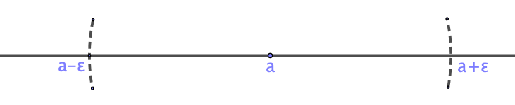

Entorno de un punto

## Conjuntos acotados

Definición

- Un subconjunto \(A \subset \mathbb{R}\) está **acotado superiormente** si existe un \(\alpha \in \mathbb{R}\) tal que \(a \leq \alpha\) para todo \(a \in A\). Al elemento \(\alpha\) se le llama **cota superior** del conjunto \(A\).
- Un subconjunto \(A \subset \mathbb{R}\) está **acotado inferiormente** si existe un \(\alpha \in \mathbb{R}\) tal que \(a \geq \alpha\) para todo \(a \in A\). En este caso \(\alpha\) es **una cota inferior** de \(A\).
- Un subconjunto \(A \subset \mathbb{R}\) está **acotado** si si està acotado superiormente e inferiormente.

## Conjuntos acotados: **Ejemplos**

**Ejemplos**.

1. \(1\) es una cota inferior del conjunto de los números naturales. Veremos más adelante que este conjunto no está acotado superiormente en \(\mathbb{R}\).
2. El conjunto \(A =\{q \in \mathbb{Q}\) tal que \(q^2 \leq 2 \}\) está acotado superiormente. Tambien lo está inferiormente.
3. El conjunto \(\{ y \mathbb{R}: y=x^2+3\}\) esta acotado inferiormente por \(3\). No lo está superiormente.

**Observación**

La existencia de una cota superior supone la existencia de infinitas cotas, puesto que cualquier número mayor que una cota superior también será una cota superior. Análogamente para las cotas inferiores: cualquier número menor que una cota inferior es también una cota inferior.

## Supremos e ínfimos

Definición

- El **supremo** de un conjunto acotado superiormente es la menor de las cotas superiores de dicho conjunto. Un conjunto puede estar acotado superiormente, pero no tener supremo (en \(\mathbb(Q)\)).
- El **ínfimo** de un conjunto acotado inferiormente es la mayor de las cotas inferiores de dicho conjunto. Tambien puede pasar que un conjunto acotado inferiormente no tenga ínfimo.

**Ejemplos**

- El subconjunto \(A\) de \(\mathbb{Q}\) definido por \(A =\{q \in \mathbb{Q}\) tal que \(q^2 \leq 2 \}\), está acotado superiormente, pero, como se ha demostrado no tiene supremo, puesto que este supremo deberia ser \(\sqrt{2}\) que no es un número racional.

## Propiedades del supremo y del ínfimo

**Proposición**

El supremo (el ínfimo) de un conjunto, si existe, és único.

**Demostración:** Supongamos que \(s_1\) y \(s_2\) son dos supremos del conjunto \(A\). Entonces, dado que \(s_1\) es supremo, es una cota superior, por lo tanto debe ser mayor o igual que el supremo \(s_2\), es decir \(s_1 \geq s_2\). Por otro lado, dado que \(s_2\) es supremo, es cota superior, por lo tanto debe ser mayor o igual que el supremo \(s_1\), es decir \(s_2 \geq s_1\). En definitiva, debe ser \(s_1=s_2\).

**Proposición**

Un número \(s\) es el supremo de un subconjunto no vacío \(A\) de \(\mathbb{R}\) si, y sólo si, \(s\) satisface las condiciones:

1. Es cota superior: \(s\geq a\), para todo \(a \in A\).
2. Es la menor de las cotas superiores: Si \(b < s\), entonces existe \(a' \in A\) tal que \(b<a'\).

## Propiedades del supremo y del ínfimo

**Proposición**

Una cota superior \(s\) de un subconjunto no vacío \(A\) de \(\mathbb{R}\), es el supremo de \(A\), si, y sólo si, para cada \(\epsilon >0\) existe un \(s_{\epsilon} \in A\), tal que \(s-\epsilon < s_\epsilon\)

**Demostración:**

\((\leftarrow)\)Supongamos que \(s\) es una cota superior que satisface la propiedad enunciada, entonces si \(a<s\), tomando \(\epsilon = s-a\), entonces \(\epsilon >0\), por lo que existe un número \(s_{\epsilon}\) tal que \(a=s-\epsilon < s_{\epsilon}\), es decir que \(a\) no es cota superior de \(A\), es decir \(s=\sup A\).

\((\rightarrow)\) Recíprocamente, supongamos que \(s = \sup A\) y sea \(\epsilon\) un número positivo. Como \(s-\epsilon <s\), \(s-\epsilon\) no es cota superior de A, por lo que debe existir \(s_{\epsilon}\) tal que \(s-\epsilon < s_{\epsilon}\).

## Máximos y mínimos

**Definición**

Si el supremo de un conjunto es un elemento del conjunto, entonces recibe el nombre de **máximo**.

Análogamente, si el ínfimo de un conjunto es un elemento del conjunto, entoces recibe el nombre de **mínimo**

**Ejemplos**

\(2\) es un máximo del conjunto \(\{x \in \mathbb{R}: x \leq 2 \}\).

Sin embargo no lo es del conjunto \(\{x \in \mathbb{R}: x < 2 \}\), del que sigue siendo el supremo.

## El axioma del supremo

Axioma del supremo

Todo subconjunto de \(\mathbb{R}\) acotado superiormente tiene supremo.

Esta es, efectivamente, una propiedad que no se satisface en \(\mathbb{Q}\), como se ha demostrado con el conjunto \(A =\{q \in \mathbb{Q}\) tal que \(q^2 \leq 2 \}\).

Resulta fácil comprobar que si \(s= \sup A\), entonces \(-s= \inf(-A)\), por lo que el axioma del supremo tambien implica que

Todo subconjunto de \(\mathbb{R}\) acotado inferiormente tiene ínfimo.

## Consecuencias del axioma del supremo.

**Proposición. (Propiedad arquimediana)**

El conjunto \(\mathbb{N}\) de los números naturales no está acotado superiormente en \(\mathbb{R}\).

**Demostración:**

Supongamos que existen cotas superiores para \(\mathbb{N}\) en \(\mathbb{R}\), por el axioma del supremo, existe \(\alpha = \sup \mathbb{N}\). Al ser \(\alpha\) la menor de las cotas superiores, resulta que \(\alpha -1\) no es cota superior. Por lo tanto existe un \(n \in \mathbb{N}\) tal que \(\alpha -1 <n\), es decir que \(\alpha < n+1\), lo cual es absurdo, puesto que habíamos supuesto que \(\alpha\) era mayor que todos los nombres naturales.

## Consecuencias del axioma del supremo.

**Corolario**

Sean \(y,z\) reales positivos. Entonces:

- Existe \(n \in \mathbb{N}\) tal que \(z<ny\).
- Existe \(n \in \mathbb{N}\) tal que \(0 <\dfrac{1}{n}<y\).
- Existe \(n \in \mathbb{N}\) tal que \(n-1 <z < n\).

## Consecuencias del axioma del supremo: Demostración.

**Demostración:**

- Considere \(\dfrac{z}{y}\), se trata de un número positivo, por consiguiente existe \(n \in \mathbb{N}\) tal que \(\dfrac{z}{y} <n\), es decir \(z < ny\).
- Inmediata a partir del resultado anterior con \(z=1\).
- El conjunto \(\{ m \in \mathbb{N}: z<m \}\) es no vacío. Sea \(n\) el primer elemento de este conjunto, entonces

\[ n-1 \leq z < n \]

## Consecuencias del Ax. del supremo: \(\sqrt{2} \in \mathbb{R}\).

**Proposición**

Existe un número real \(p \in \mathbb{R}\) tal que \(p^2 = 2\).

**Demostración:**

Consideremos el conjunto \(M = \{r \in \mathbb{R}: r^2 <2 \}\). \(M\) es un subconjunto acotado de \(\mathbb{R}\) (¿Por qué?). Sea \(p = \sup M\). Demostraremos que \(p^2 =2\).

Supongamos, en primer lugar, que \(p^2<2\), veamos que existe \(\epsilon >0\), tal que \((p+ \epsilon)^2 <2\). Con este fin, supongamos que, efectivamente, existe un tal \(\epsilon\), entonces seria \(p^2+2p \epsilon +{\epsilon}^2 <2\) y, por lo tanto debería ser

\[ \epsilon < \dfrac{2-p^2}{2p+\epsilon} \]

Consideremos ahora \(\epsilon = \min \left\{1,\dfrac{2-p^2}{2p+1} \right\}\), entonces tenemos que \(\epsilon < \dfrac{2-p^2}{2p+1} < \dfrac{2-p^2}{2p+\epsilon}\), por lo tanto es \((p+\epsilon)^2 < 2\), es decir \((p+\epsilon) \in M\) y como \(\epsilon >0\), esto contradice que \(p= \sup M\).

## \(\sqrt{2} \in \mathbb{R}\) (Continuación)

**Demostración (Continuación):**

Supongamos ahora que \(p^2>2\). Veremos que existe \(\epsilon >0\) tal que \((p-\epsilon)^2 >2\), por lo que \(p\) tampoco podrá ser el supremo de \(M\). Ahora, si \((p-\epsilon)^2 >2\), debe ser \(p^2-2p\epsilon+\epsilon^2>2\), es decir, \(p^2-2 > \epsilon(2p -\epsilon)\), es decir \[ \epsilon < \dfrac{p^2-2}{2p-\epsilon} \] Si ahora consideramos \(\epsilon = \frac{p^2 -2}{2p}\), está claro que para este \(\epsilon >0\) es \(\epsilon = \dfrac{p^2 -2}{2p}> \dfrac{p^2-2}{2p-\epsilon}\), es decir que \((p-\epsilon)^2 >2\), y por lo tanto \(p\) tampoco puede ser el supremo de \(M\) si \(p^2 >2\).

En definitiva, sólo queda la opción que el supremo \(p\) del conjunto \(M\), sea tal que \(p^2=2\), es decir que \(\sqrt{2}\) és un número real.

**Corolario**

Para todo número real positivo \(b\), existe un número real positivo \(\beta\) tal que \(\beta^2 =b\).

## Los números irracionales (1)

Acabamos de demostrar que hay números en \(\mathbb{R}\) que no estan \(\mathbb{Q}\), como seria el caso de \(\sqrt{2}\). Por lo tanto el conjunto de los números reales que no son racionales, \(\mathbb{R} \setminus \mathbb{Q}\), és un conjunto no vacio. Es el conjunto de los números irracionales .

Este nombre indica que estos números no se pueden expresar como el cociente -la razón- de dos enteros.

Conviene observar que ni la suma ni el producto de dos números irracionales tienen porqué ser números irracionales. (Por ejemplo \(\sqrt{2} \cdot \sqrt{2} = 2\))

## Los números irracionales (2)

Hemos visto que todo número real está entre dos enteros, es decir, dado un \(r \in \mathbb{N}\), existe un \(n \in \mathbb{Z}\) tal que \(n \leq r < n+1\). Se puede demostrar que dado un número irracional existe una representación decimal de dicho número, es decir, existen \(b_1,b_2, \ldots, b_n, \ldots\), con no todos igual a \(9\), tales que \[ r = n.b_1b_2b_3 \ldots b_n \ldots \]

Es importante observar que, la representación decimal de los números irracionales constará siempre de un número ilimitado de cifras que no se repiten de forma periódica, puesto que como es sabido, una representación decimal con un número limitado de cifras o que se repitan periódicamente siempre corresponde a un número racional.

## Más consecuencias del axioma del supremo.

**Proposición. \(\mathbb{Q}\) es denso en \(\mathbb{R}\)**

Sean \(x,y \in \mathbb{R}\) tales que \(x<y\), entonces existe \(q \in \mathbb{Q}\) tal que \(x<q<y\). Es decir, entre dos números reales siempre hay un número racional.

**Demostración:**

Supongamos que \(x>0\), entonces \(y-x >0\) y, por la propiedad arquimediana, existe \(n \in \mathbb{N}\) tal que \(\dfrac{1}{n} <y-x\), es decir que \(ny-nx >1\).

Dado que \(nx >0\), existe \(m \in \mathbb{N}\) tal que \(m-1 <nx<m\).

\(m\) también verifica \(m<ny\), ya que \(m< nx+1<ny\). En definitiva es \(nx<m<ny\) y, por lo tanto

\[ x<\dfrac{m}{n}<y \] es decir, \(q = \dfrac{m}{n}\) es el número racional buscado. Razonamientos análogos sirven para el caso \(x<0\).

## Más consecuencias del axioma del supremo.

**Corolario**

Si \(x,y \in \mathbb{R}\), con \(x<y\), entonces existe un número irracional z (es decir que \(z \in \mathbb{R} \setminus \mathbb{Q}\)) tal que \(x<z<y\). Es decir, entre dos numeros reales, siempre hay un número irracional.

**Demostración:**

Consideremos \(s \in \mathbb{R} \setminus \mathbb{Q}\) (por ejemplo \(\sqrt{2}\)), \(s>0\), entonces, sabemos que existe un racional \(q \in \mathbb{Q}\) tal que \(\dfrac{x}{s} <q < \dfrac{y}{s}\). Ahora \(qs \in \mathbb{R} \setminus \mathbb{Q}\), puesto que si \(z=qs \in \mathbb{Q}\), \(s=\dfrac{z}{q}\) seria el cociente de dos racionales y, por la tanto racional. En definitiva es \(x<z<y\), con \(z\) irracional.

## Cardinal de un conjunto: Conjuntos infinitos.

Esta sección está destinada a comparar el “tamaño” de los conjuntos de números \(\mathbb{N}\), \(\mathbb{Z}\), \(\mathbb{Q}\) y \(\mathbb{R}\). Veremos que, en tanto que los tres primeros tienen el mismo tamaño, en un sentido que se definirá, el de los números reales es mayor, es decir que hay muchos más números irracionales que racionales. Cantor fue el primero que lo descubrió, la cual cosa le supuso no pocos problemas ante la incomprensión de una buena parte de los matemáticos contemporáneos.

## Aplicaciones

Para lo que sigue, es conviente recordar que una **aplicación**, \(f\) de un conjunto \(A\) en otro \(B\), representada por \(f: A \rightarrow B\), es una asignación de elementos de \(B\) a elementos de \(A\), de tal manera a que cada elemento de \(A\) le corresponde uno, y sólo uno, elemento de \(B\).

Escribiremos \(b=f(a)\), y diremos que \(b\) *es la imagen de* \(a\) por \(f\), para indicar que \(b\) es un elemento asignado a \(a\).

## Cardinal de un conjunto: Conjuntos infinitos.

Una aplicación, \(f\), es **inyectiva** si a elementos distintos de \(A\) le corresponden elementos diferentes de \(B\), es decir si \(a_1 \neq a_2\) entonces \(f(a_1) \neq f(a_2)\), para todo \(a_1\) y \(a_2\) de \(A\).

Una aplicación es **exhaustiva** si todos los elementos de \(B\) son la imagen de algún elemento de \(A\), es decir si para todo \(b \in B\), existe un \(a \in A\) tal que \(b=f(a)\).

Finalmente, una aplicación es **biyectiva** si es inyectiva y exhaustiva a la vez. A menudo, una aplicación biyectiva también es llamada **correspondencia uno a uno**.

**Ejemplo de aplicación**

\(f: \mathbb{N} \rightarrow \mathbb{N}\) definida por \(f(n) = 2n\) es una aplicación del conjunto de los números naturales en sí mismo. Por otro lado, la misma asignación entre \(\mathbb{Z}\) y \(\mathbb{N}\), no es una aplicación, puesto que el doble de un número negativo no es un número natural.

## Ejemplos de aplicaciones

**Ejemplo de aplicación inyectiva**

**Ejemplo 1.** Sean \(n \in \mathbb{N}\) y \(N_n\) el conjunto de los \(n\) primeros números naturales. La aplicación \(f(k)=k\) de \(N_n \rightarrow \mathbb{N}\) es inyectiva, pero no exhaustiva, ya que cualquier natural mayor que \(n\) no es imagen de ningún elemento de \(N_n\).

**Ejemplo 2.**

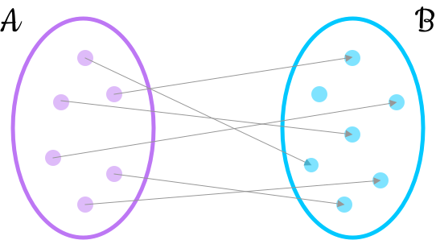

Es inyectiva porque no hay dos elementos de \(\cal{B}\) que sean imagen del mismo elemento de \(\cal{A}\). No es exhaustiva porque hay un elemento de \(\cal{B}\) que no es imagen de ninguno de \(\cal{A}\).

## Ejemplos de aplicaciones

**Ejemplo de aplicación exhaustiva**

La aplicación \(h: \mathbb{Z} \rightarrow \mathbb{N}\), definida por \(h(n)=|n|\), es una aplicación exhaustiva, pero no inyectiva, puesto que \(h(n)=h(-n)\).

**Otro ejemplo** es el que viene representado por el esquema:

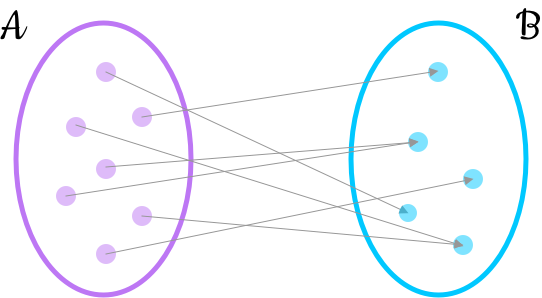

Se trata de una aplicación exhaustiva porque todos los elementos de \(\cal{B}\) son imagen de alguno de \(\cal{A}\), pero hay dos pares de elementos de \(\cal{A}\) que tienen la misma imagen.

## Ejemplos de aplicaciones

**Ejemplo de aplicación biyectiva**

La aplicación de \(f: \mathbb{N} \rightarrow \mathbb{Z}\) definida por \[ f(n) = \begin{cases} \dfrac{n}{2}, & \text{ si n es par}\\ -\dfrac{n+1}{2},& \text{ si n es impar} \end{cases} \] es una aplicación biyectiva.

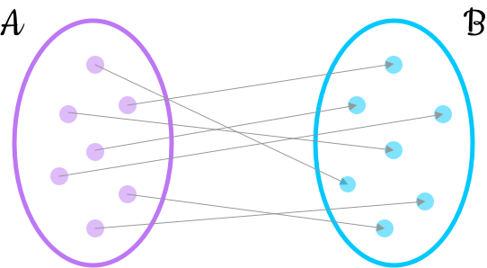

## Cardinal de un conjunto: Conjuntos infinitos.

**Definición: Conjunto finito**

Sea \(N_n\) el conjunto de los \(n\) primeros números naturales. Diremos que un conjunto \(A\) tiene \(n\) elementos si existe una correspondencia uno a uno entre \(A\) y \(N_n\).

Un conjunto **finito** es un conjunto con \(n\) elementos. Es decir, un conjunto \(A\) es finito si existe una aplicación biyectiva de \(A\) en un subconjunto de números naturales de la forma \(N_n\).

Un conjunto es **infinito** si no es finito.

**Definición. Cardinal de un conjunto**

Dos conjuntos \(A\) y \(B\) tienen el mismo **cardinal** si existe una correspondencia uno a uno entre ellos.

## \(\mathbb{N}\) es infinito.

**Proposición**

El conjunto de los números naturales, \(\mathbb{N}\), es infinito.

**Demostración**

Es suficiente demostrar que para todo \(m \in \mathbb{N}\) no puede existir una aplicación inyectiva de \(\mathbb{N}\) en \(N_m\), puesto que, de ser así, no podrá existir una aplicación biyectiva entre esos dos conjuntos y, por lo tanto \(\mathbb{N}\) no será un conjunto finito.

Ahora, en primer lugar, cada subconjunto de \(\mathbb{N}\) de \(m\) elementos se puede poner en correspondencia uno a uno com \(N_m\), por lo tanto será suficiente considerar el propio \(N_m = \{1,2, \ldots, m\}\) como subconjunto de \(\mathbb{N}\). Una vez que hemos asignado la imagen de estos primeros \(m\) elementos de \(\mathbb{N}\) hemos agotado los elementos de \(N_m\), por consiguiente, para asignar una imagen a \(m+1 \in \mathbb{N}\) no quedará más remedio que tomar alguno de los elementos de \(N_m\) y, por lo tanto tendríamos dos naturales distintos con la misma imagen, lo que significa que la aplicación no puede ser inyectiva.

La técnica aplicada en la demostración anterior, se conoce con el nombre del **Principio del palomar** y resulta ser extremadamente útil en la resolución de diversos tipos de problemas.

## Conjuntos numerables.

Está claro que dos conjuntos finitos con el mismo número de elementos tienen el mismo cardinal, pero ¿qué pasa con los conjuntos infinitos?

Hemos visto un ejemplo de una aplicación biyectiva entre los conjuntos \(\mathbb{Z}\) y \(\mathbb{N}\) y, por lo tanto tienen el mismo cardinal, aunque \(\mathbb{N} \subset \mathbb{Z}\). Conviene observar que esta es una característica de los conjuntos infinitos: pueden tener el mismo cardinal que alguno de sus subconjuntos propios.

**Definición: Conjunto numerable**

Diremos que un conjunto es **numerable** si tiene el mismo cardinal que \(\mathbb{N}\). Diremos que un conjunto es **contable** si es finito o numerable.

## Conjuntos contables

**Proposición**

Si \(A\) es contable y \(B \subset A\), entonces \(B\) es contable.

**Demostración**

La aplicación \(i: B \rightarrow A\) que envia cada elemento a si mismo es inyectiva, por lo tanto el cardinal de \(B\) es a lo sumo el de \(A\).

**Ejemplos**

1.El conjunto \(\mathbb{Z}\) de los números enteros es numerable.

1. También lo es el conjunto de los números naturales pares y, más en general, el de los múltiplos de un número natural, \(k\).
2. Si \(A\) es un conjunto numerable y \(f:A \rightarrow B\) es una aplicación, entonces \(f(A)\) es numerable, puesto que \(f(A)\) tiene a lo sumo (caso que f sea inyectiva) tantos elementos como \(A\)

## \(\mathbb{Q}\) es numerable

**Proposición (Cantor)**

El conjunto \(\mathbb{Q}\) es numerable.

**Demostración**

El resultado se sigue del hecho que la aplicación \(f: \mathbb{Q} \rightarrow \mathbb{N}\) definida por \[ f \left(\dfrac{m}{n} \right) = \dfrac{1}{2}(m+n-2)(m+n-1)+m \] es biyectiva.

A continuación se muestra una “demostración” visual de que \(\mathbb{Q}\) es numerable.

## \(\mathbb{Q}\) es numerable

El gráfico muestra cómo disponer los elementos de \(\mathbb{Q}\) para numerarlos.

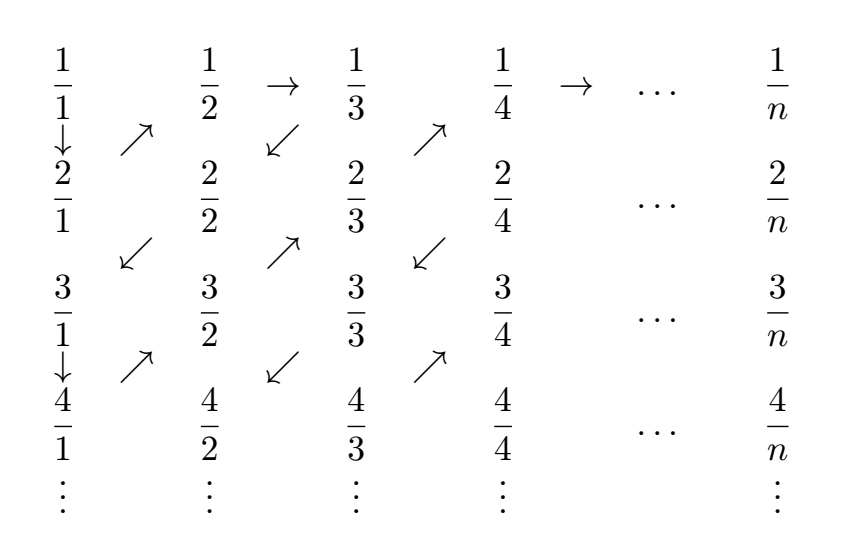

## \(\mathbb{R}\) no es numerable

**Proposición**

El conjunto de los números reales, \(\mathbb{R}\), no es numerable.

**Demostración**

Demostraremos que el intervalo abierto \((0,1) \subset \mathbb{R}\) no es numerable y, por lo tanto, el conjunto \(\mathbb{R}\) no podrá ser numerable. Supongamos que si, que \((0,1)\) es numerable. Es decir que podemos disponer estos números, en su representación decimal, de manera que uno sea el primero, otro el segundo, y así sucesivamente: \[ a_1 = 0.a_{11}a_{12}a_{13} \ldots a_{1n} \ldots \\ a_2 = 0.a_{21}a_{22}a_{23} \ldots a_{2n} \ldots \\ a_3 = 0.a_{31}a_{32}a_{33} \ldots a_{3n} \ldots \\ \ldots\\ a_m = 0.a_{m1}a_{m2}a_{m3} \ldots a_{mn} \ldots\\ \ldots \] Consideremos ahora el número \(a=0.b_1b_2b_3 \ldots b_n \ldots\), en el que cada \(b_k=a_{kk}+1\), si \(a_{kk} \neq 9\), y \(b_k = 0\), si \(a_{kk} = 9\). El número \(a\) no está en la lista de números anterior, puesto que si ocupase el lugar \(k\) diferiria del correspondiente \(a_k\) precisamente en la cifra que ocupa el lugar \(k\).

## El conjunto de los números irracionales no es numerable

**Proposición**

La reunión de dos conjuntos finitos es un conjunto finito.

La reunión de dos conjuntos numerables es numerable.

La reunión de dos conjuntos contables es contable.

**Proposición**

El conjunto de los numeros irracionales no es numerable.

**Demostración**

Dado que \(\mathbb{R} = \mathbb{Q} \cup (\mathbb{R} \setminus \mathbb{Q})\), se sigue que \(\mathbb{R} \setminus \mathbb{Q}\) no puede ser numerable, puesto que si lo fuera, dado que \(\mathbb{Q}\) es numerable, también lo seria \(\mathbb{R}\), y ya hemos visto que no es así.

## Intervalos anidados (1)

**Definición: Sucesión de intervalos anidados**

Una sucesión de **intervalos anidados** es un conjunto de intervalos cerrados y acotados de \(\mathbb{R}\), \(I_n = [a_n,b_n]\), tal que para todo \(n \in \mathbb{N}\), es \(I_{n+1} \supset I_n\) o, lo que es equivalente, tal que \(a_n \leq a_{n+1} \leq b_{n+1} \leq b_n\)

**Observación**

Como se verá más adelante, un conjunto indexado por los números naturales, como lo son \(\{I_n\}\), \(\{a_n\}\) y \(\{b_n\}\), recibe el nombre de **sucesión**

## Intervalos anidados (2)

**Proposición.**

Sea \(\{I_n\}_{n \in \mathbb{N}}\) una sucesión de intervalos anidados de \(\mathbb{R}\). Entonces existe un \(\xi \in \mathbb{R}\) tal que \(\xi \in I_n\) para todo \(n \in \mathbb{N}\), o lo que es lo mismo, tal que \(a_n \leq \xi \leq b_n\), para todo \(n \in \mathbb{N}\)

**Demostración**

En primer lugar, veamos que \(a_k \leq b_n\) para todo \(k\) y para todo \(n\): Si \(n \leq k\), entonces \(I_k \subset I_n\) y, por lo tanto, \(a_k \leq b_k \leq b_n\). Por otra parte, si \(k < n\), entonces \(I_k \supset I_n\) y, por lo tanto, \(a_k \leq a_n \leq b_n\)

Es decir, el conjunto de extremos inferiores de los intervalos \(\{a_n: n \in \mathbb{N}\}\) está acotado superiormente por cualquiera de los \(b_n\). Sea \(\xi\) el supremo de este conjunto. Está claro que \(a_n \leq \xi\), para todo \(n \in \mathbb{N}\), puesto que \(\xi\) es el supremo de todos los \(a_n\).

Pero todos los \(b_n\) son cotas superiores de este conjunto, y el supremo es la menor de las cotas superiores, por lo que \(\xi \leq b_n\), para todo n. En definitiva es \(a_n \leq \xi \leq b_n\), para todo \(n \in \mathbb{N}\) o, lo que es lo mismo, \(\xi \in I_n\) para todo \(n \in \mathbb{N}\).

## Principio de los intervalos anidados.

**Proposición: Principio de los intervalos anidados**

Sea \(I_n = [a_n,b_n]\) una sucesión de intervalos anidados tales que \(\inf\{b_n-a_n: n \in \mathbb{N}\}=0\). Entoces existe un único punto \(\xi\) que está en todos los intervalos \(I_n\).

**Demostración**

Hemos visto en la proposición anterior que \(\xi = \sup\{a_n: n \in \mathbb{N} \}\) está en todos los \(I_n\). Un razonamiento similar al de la proposición anterior se demuestra que \(\eta = \inf \{b_n: n \in \mathbb{N} \}\) tambien está en todos los intervalos. Sólo falta comprobar que \(\xi = \eta\). Ahora bien:

Dado que \(\eta \leq b_n\) y que \(\xi\geq a_n\), para todo \(n\), tenemos que \(0 \leq \eta - \xi \leq b_n -a_n\), para todo \(n\), por lo tanto \(0 \leq \eta - \xi \leq \inf\{b_n-a_n: n \in \mathbb{N}\}=0\), es decir que \[ \xi = \eta \] Por lo tanto este es el único punto que está en todos los intervalos, puesto que cualquier punto \(x\) que esté en todos los intervalos es mayor que todos \(a_n\) y menor que todos los \(b_n\) y, por lo tanto seria \(\xi \leq x \leq \eta\).

## Puntos de acumulación

Veremos en el apartado de funciones que, a menudo, tenemos una función definida en todos los puntos próximos a uno dado, pero que no lo está es ese punto. Tal sería el caso, por ejemplo de la función \(f(x)= \frac{\sin x}{x}\): no está definida en el punto \(0\), pero si lo está en todos los puntos de cualquier entorno reducido del \(0\). Para tratar este tipo de situaciones será útil lo que sigue.

**Definición: Punto de acumulación**

Sean \(A\) y \(\xi\) un subconjunto y un punto de \(\mathbb{R}\) respectivamente. \(\xi\) es un **punto de acumulación** de \(A\), si en todo entorno abierto de \(\xi\) hay puntos de \(A\) diferentes de \(\xi\).

Obsérvese que la definición anterior también se puede hacer en términos de los **entornos reducidos** de un punto, es decir del conjunto de puntos del entorno diferentes del centro: Un punto \(\xi\) es de acumulación del conjunto \(A\) si en todo entorno reducido del punto \(\xi\) hay puntos de \(A\).

## Puntos de acumulación: **Ejemplos**

**Ejemplos**

**Ejemplo 1.** Los extremos \(a\),\(b\) de un intervalo abierto \((a,b)\), son puntos de acumulación del intervalo. Son ejemplos de puntos de acumulación de un conjuunto que no pertenecenc al conjunto.

**Ejemplo 2.** Sea \(A=\{c\} \cup [a,b]\), donde \(c \in \mathbb{R} \setminus [a,b]\). Entonces \(c\) no es un punto de acumulación de \(A\), en tanto que todos los puntos del intervalo \([a,b]\) lo son. De hecho los puntos del intervalo cerrado \([a,b]\) son los únicos puntos de acumulación del intervalo.

**Ejemplo 3.** El conjunto \(\mathbb{N}\) de los números naturales no tiene puntos de acumulación: \(n\) es el único natural en el intervalo abierto \((n-1,n+1)\).

## Puntos de acumulación: Caracterización

**Proposición**

\(\xi \in \mathbb{R}\) es un punto de acumulación de \(A\) si, y sólo si, en cada entorno de \(\xi\) hay infinitos puntos de \(A\).

**Demostración**

Supongamos que dado un \(\epsilon >0\), en el entorno de \(\xi\) definido por \((\xi - \epsilon, \xi+\epsilon)\) hay sólo un número finito de puntos de A: \(\{a_1, \ldots, a_k\}\) distintos de \(\xi\). Sea ahora \(\delta = \inf\{ |a_i-\xi|: i=1,\ldots,k\}\). Es evidente que si \(x\) es un punto del entorno abierto \((\xi-\delta,\xi+\delta)\), entonces es \(|x-\xi|<\delta\), por lo que no puede ser uno de los \(a_i\) y, por lo tanto, este seria un entorno de \(\xi\) sin puntos de \(A\) diferentes de \(\xi\), lo que contradice que \(\xi\) sea un punto de acumulación de \(A\).

El recíproco es inmediato.

## Teorema de Bolzano-Weierstrass

**Proposición: Teorema de Bolzano-Weierstrass**

Todo conjunto de números reales infinito y acotado tiene un punto de acumulación.

**Demostración**

Sea \(A\subset \mathbb{R}\) infinito y acotado, veremos que tiene un punto de acumulación.

Por estar \(A\) acotado, es decir que existe \(K>0\) tal que \(|a|<K\) para todo \(a \in A\), es \(A \subset [-K,K]\).

Por tener \(A\) infinitos puntos, en al menos uno de los intervalos \([-K,0]\) y \([0,K]\) hay infinitos puntos de \(A\). Sea \(I_1 =[a_1,b_1]\) esta mitad. (Si los hay en los dos, nos quedamos con el de la izquierda, por ejemplo). Conviene observar que \(|b_1-a_1|=\dfrac{K}{2}\).

Dado que en \(I_1 =[a_1,b_1]\) hay infinitos puntos de \(A\), podemos repetir el proceso y determinar así un intervalo \(I_2 = [a_2,b_2]\), que seria una de las dos mitades \([a_1, \frac{a_1+b_1}{2}]\) o \([\frac{a_1+b_1}{2},b_1]\), con infinitos puntos de \(A\) y tal que \(I_2 \subset I_1\) y que \(b_2-a_2= \dfrac{b_1 - a_1}{2}= \dfrac{K}{2^2}\).

## Teorema de Bolzano-Weierstrass (cont.)

**Demostración**

Reiterando este proceso, construiremos una sucesión \(I_n\) de intervalos anidados \(I_n\), tal que \(I_{n+1} \subset I_n\) y \(b_n-a_n = \dfrac{K}{2^n}\).

Además, el \(\inf \left\{\dfrac{k}{2^n}: n \in \mathbb{N} \right\}\), existe puesto que se trata de un conjunto acotado inferiormente por \(0\). Este ínfimo no puede ser positivo, puesto que si existe \(0 < r <\dfrac{1}{2^n}\) para todo \(n \in \mathbb{N}\), resultaria que tendria que ser \(2^n < \dfrac{1}{r}\), o lo que es lo mismo, \(n \log 2 <-\log r\) y, por lo tanto, \(n < -\dfrac{\log r}{\log 2}\), lo que significaría que los números naturales estan acotados en \(\mathbb{R}\) y ya hemos visto que no puede ser.

Ahora, por el principio de los intervalos anidados, tendremos que hay un solo punto \(\xi\) que está en todos los intervalos. \(\xi\) es el punto de acumulación buscado, puesto que por ser \(\xi\) el infimo de los \(b_n\) y el supremo de los \(a_n\), dado un \(\epsilon >0\), existe un \(n \in \mathbb{N}\) tal que \(\xi-\epsilon \leq a_n \leq \xi \leq b_n \leq \xi+ \epsilon\), y, por lo tanto, cualquier entorno de \(\xi\) contiene infinitos puntos de \(A\).

## Recta real ampliada

A menudo será conveniente considerar conjuntos como \(\{ x \in \mathbb{R}: x \geq a \}\) o \(\{x \in \mathbb{R}: x \leq a \}\), donde \(a\) indica un número real. Para referirnos a estos conjuntos es útil introducir los símbolos más infinito, \(+ \infty\), y menos infinito, \(- \infty\), tales que, para todo número real \(x\) es \(-\infty < x < +\infty\). Siendo así, podemos escribir \[ \{ x \in \mathbb{R}: x \geq a \} = [a,+\infty) \quad \text{ y } \quad \{ x \in \mathbb{R}: x \leq a \} = (-\infty,a] \] **Definición: Recta real ampliada.**

Llamamos **recta real ampliada**, \(\overline{\mathbb{R}}\) al conjunto resultante de añadir los símbolos \(-\infty\) y \(+\infty\) al conjunto de los números reales, es decir

\[ \overline{\mathbb{R}} = \mathbb{R} \cup \{ -\infty,+\infty \} \]

## Operaciones aritméticas en la recta real ampliada

Obsérvese que, con la introducción de estos símbolos, podemos escribir:

\[ \mathbb{R}=(-\infty,+\infty) \quad \text{ y } \quad \overline{\mathbb{R}} = [-\infty,+\infty] \] También es posible extender las operaciones aritméticas a \(- \infty\) y \(+\infty\). Lo hacemos en la forma que indican las tablas siguientes:

| \(x+(+\infty) = +\infty\) | \(x+(-\infty) = -\infty\) |
| --- | --- |
| \(x-(+\infty) = -\infty\) | \(x-(-\infty) = +\infty\) |
| \(x \cdot (+\infty) = +\infty\), si \(x>0\) | \(x \cdot (+\infty) = -\infty\), si \(x<0\) |
| \(x \cdot (-\infty) = -\infty\), si \(x>0\) | \(x \cdot (-\infty) = +\infty\), si \(x<0\) |

## Operaciones aritméticas en la recta real ampliada

| \(\dfrac{x}{+\infty} =0\) | \(\dfrac{x}{-\infty} =0\) |
| --- | --- |
| \((+\infty) + (+\infty) = +\infty\) | \((-\infty) + (-\infty)= -\infty\) |
| \((+\infty) \cdot (+\infty) = +\infty\) | \((+\infty) \cdot (-\infty) = -\infty\) |
| \((-\infty) \cdot (-\infty) = +\infty\) |  |

## Indeterminaciones

Las operaciones siguientes tienen un resultado indeterminado: \[ \infty - \infty, \quad 0\cdot (\pm \infty), \quad 1^{\infty}, \quad \frac{0}{0}, \quad \frac{\infty}{\infty}, \quad 0^0, \quad \infty^0 \]

[output not shown]

[output not shown]